# Homework 6

### Exercise 9

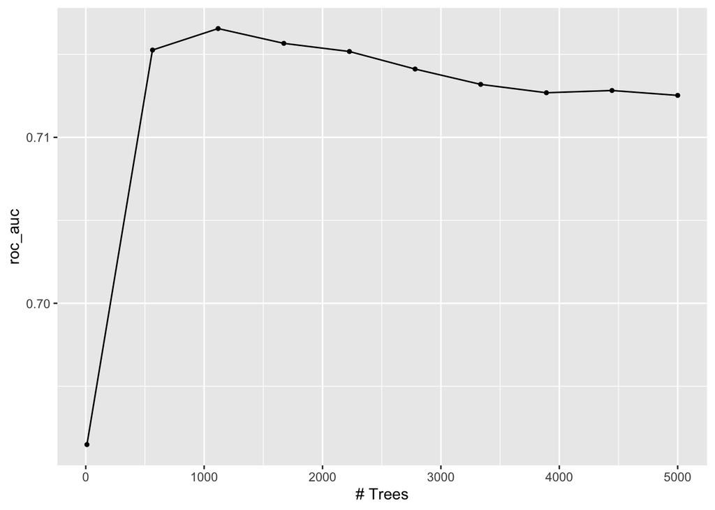

```r
boost_spec <- boost_tree() %>%
  set_engine("xgboost") %>%
  set_mode("classification")
boost_wf <- workflow() %>%
  add_model(boost_spec %>% set_args(trees = tune())) %>%
  add_recipe(pokemon_recipe)
boost_grid <- grid_regular(trees(range = c(10, 5000)), levels = 10)
tune_boost <- tune_grid(
  boost_wf,
  resamples = pokemon_fold,
  grid = boost_grid,
  metrics = metric_set(roc_auc))
autoplot(tune_boost)
```

What do you observe?

ROC AUC is best with more than 500 trees.

What is the `roc_auc` of your best-performing boosted tree model on the folds? *Hint: Use `collect_metrics()` and `arrange()`.*

```r
arrange(collect_metrics(tune_boost), desc(mean))
```

```
## # A tibble: 10 × 7
##    trees .metric .estimator  mean     n std_err .config
##    <int> <chr>   <chr>      <dbl> <int>   <dbl> <chr>
##  1  1118 roc_auc hand_till  0.717     5  0.0164 Preprocessor1_Model03
##  2  1673 roc_auc hand_till  0.716     5  0.0162 Preprocessor1_Model04
##  3   564 roc_auc hand_till  0.715     5  0.0171 Preprocessor1_Model02
##  4  2227 roc_auc hand_till  0.715     5  0.0166 Preprocessor1_Model05
##  5  2782 roc_auc hand_till  0.714     5  0.0170 Preprocessor1_Model06
##  6  3336 roc_auc hand_till  0.713     5  0.0171 Preprocessor1_Model07
##  7  4445 roc_auc hand_till  0.713     5  0.0168 Preprocessor1_Model09
##  8  3891 roc_auc hand_till  0.713     5  0.0168 Preprocessor1_Model08
##  9  5000 roc_auc hand_till  0.713     5  0.0167 Preprocessor1_Model10
## 10    10 roc_auc hand_till  0.691     5  0.0245 Preprocessor1_Model01
```

```r
best_boost <- select_best(tune_boost, metric = "roc_auc")
#0.7165574
```

### Exercise 10

Display a table of the three ROC AUC values for your best-performing pruned tree, random forest, and boosted tree models. Which performed best on the folds? Select the best of the three and use `select_best()`, `finalize_workflow()`, and `fit()` to fit it to the *testing* set.

```r
compl <- collect_metrics(tune_res)
roc_compl <- subset(compl, .config=='Preprocessor1_Model03')[,4]
roc_compl$type <- c('pruned tree')

forest <- collect_metrics(tune_random)
roc_forest <- subset(forest, .config =='Preprocessor1_Model188')[,6]
roc_forest$type <- c('random forest')


boost <- collect_metrics(tune_boost)
roc_boost <-subset(boost, .config == 'Preprocessor1_Model03')[,4]
roc_boost$type <- c('boosted tree')


x<-rbind(roc_compl, roc_forest, roc_boost )
table <-  x[,c(2,1)] %>% rename(roc_auc = mean)
table
```

[output not shown]

```r
final <- finalize_workflow(boost_wf, best_boost)
final_fit <- fit(final, data = pokemon_train)
```

Print the AUC value of your best-performing model on the testing set. Print the ROC curves. Finally, create and visualize a confusion matrix heat map.

```r
aug <- augment(final_fit, new_data = pokemon_test)
aug %>% roc_auc(truth = type_1, estimate = c(
  .pred_Bug, .pred_Fire, .pred_Grass, .pred_Normal,
  .pred_Psychic, .pred_Water))
```

```
## # A tibble: 1 × 3
##   .metric .estimator .estimate
##   <chr>   <chr>          <dbl>
## 1 roc_auc hand_till      0.709
```

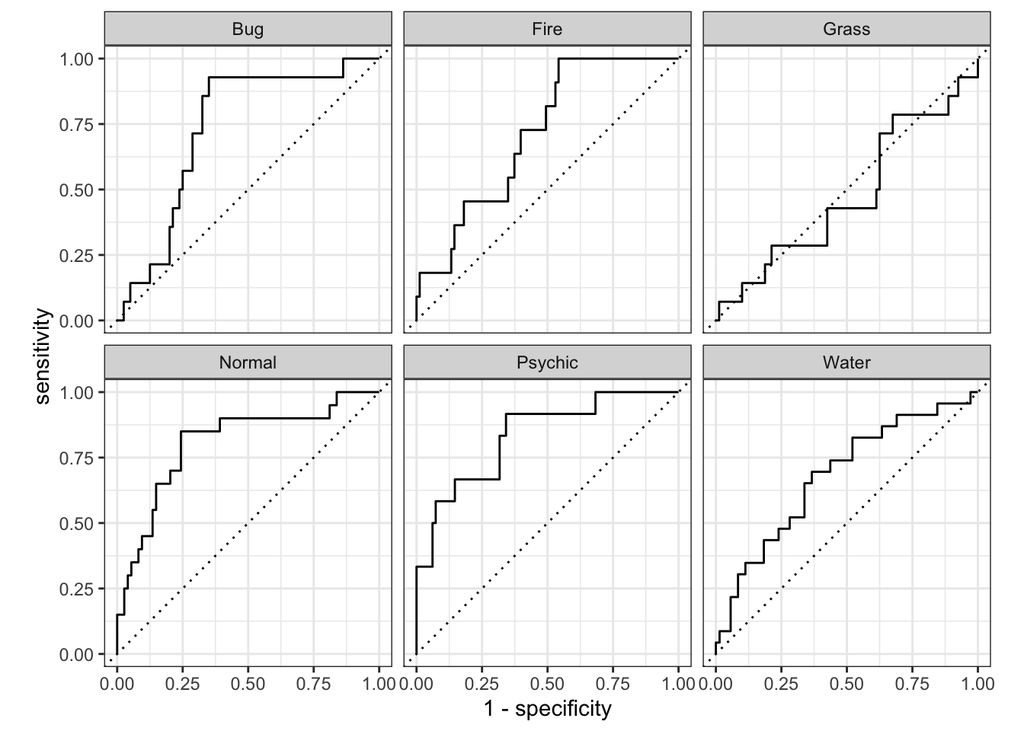

```r
aug %>% roc_curve(truth = type_1, estimate = c(.pred_Bug, .pred_Fire, .pred_Grass, .pred_Normal, .pred_Psychic, .pred_Water)) %>% autoplot()
```

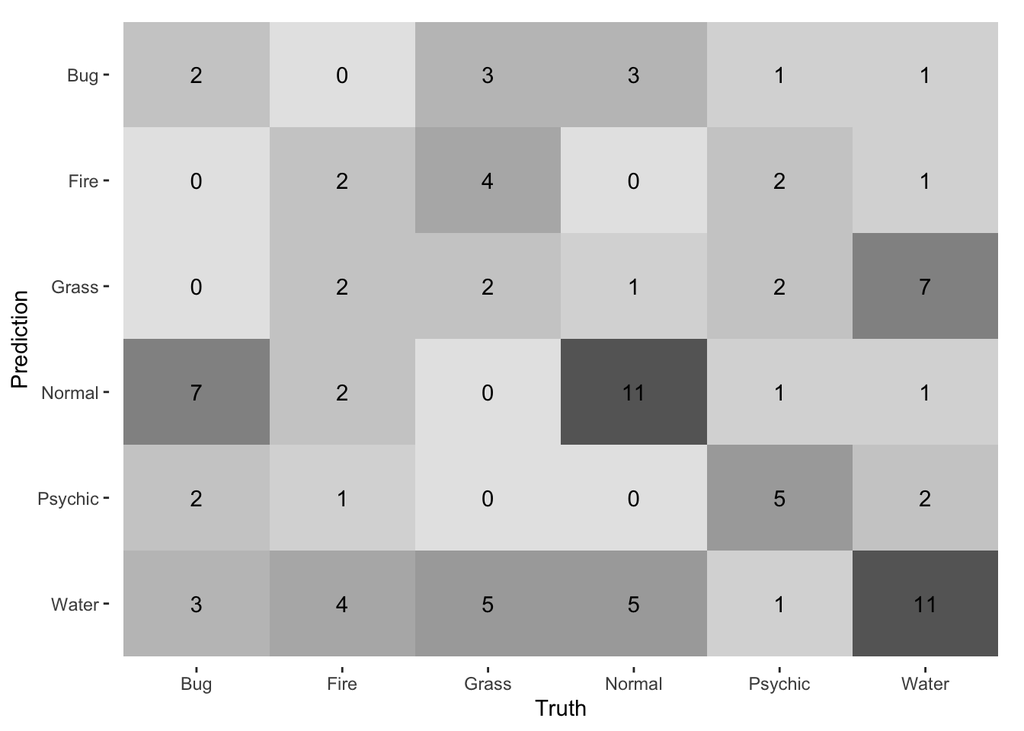

```r
aug %>% conf_mat(truth = type_1, estimate = .pred_class) %>% autoplot(type = "heatmap")
```

Which classes was your model most accurate at predicting? Which was it worst at?

Most accurate for Normal type and least accurate for Grass type.

## 231

### Exercise 11

Using the `abalone.txt` data from previous assignments, fit and tune a random forest model to predict `age`. Use stratified cross-validation and select ranges for `mtry`, `min_n`, and `trees`. Present your results. What was the model’s RMSE on your testing set?

```r
abalone <- read_csv("abalone.csv")
```

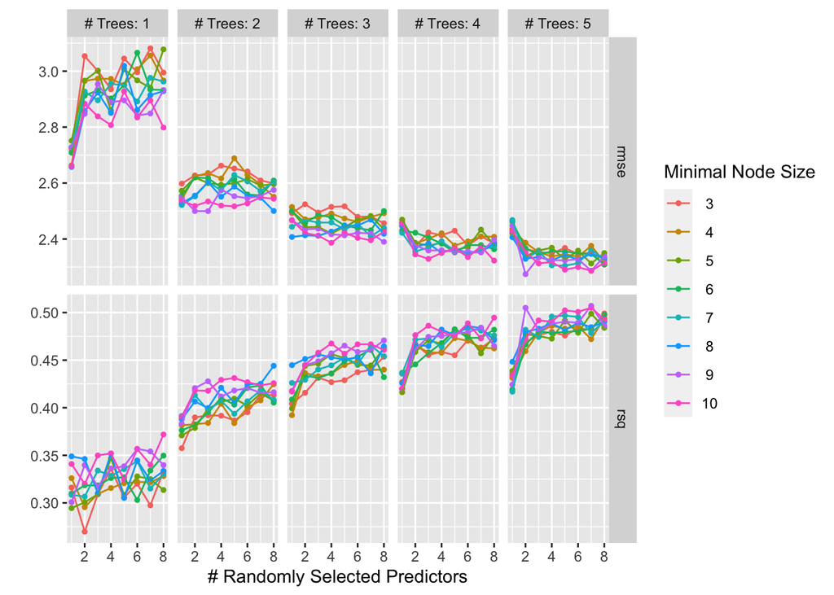

```r
age <- abalone$rings + 1.5
abalone$age <- age
set.seed(777)
abalone_split <- initial_split(abalone, prop = 0.80, strata = age)
abalone_train <- training(abalone_split)
abalone_test <- testing(abalone_split)
abalone_fold <- vfold_cv(abalone, v = 5, strata = "age")
abalone_recipe <- recipe(age ~ . , data = abalone_train) %>%
  step_rm(rings) %>%
  step_dummy(all_nominal_predictors()) %>%
  step_interact(terms = ~ starts_with("type"):shucked_weight +
                  longest_shell:diameter +
                  shucked_weight:shell_weight) %>%
  step_normalize(all_predictors())
abalone_spec <- rand_forest() %>%
  set_engine("ranger", importance = "impurity") %>%
  set_mode("regression")
abalone_wf <- workflow() %>%
  add_model(abalone_spec %>% set_args(mtry = tune(), trees = tune(), min_n = tune())) %>%
  add_recipe(abalone_recipe)
abalone_grid <- grid_regular(mtry(range = c(1,8)), trees(range = c(1, 5)), min_n(range = c(3,10)), levels = 8)
tune_abalone <- tune_grid(
  abalone_wf,
  resamples = abalone_fold,
  grid = abalone_grid)
autoplot(tune_abalone)
```

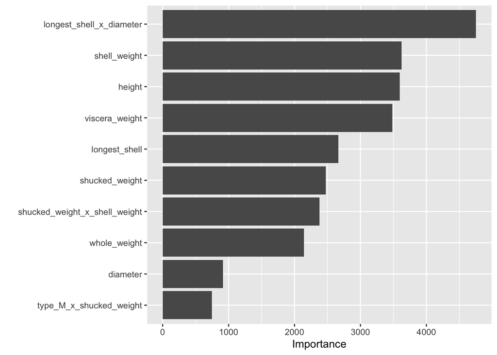

```r
best_abalone <- select_best(tune_abalone, metric = "rmse")
abalone_final <- finalize_workflow(abalone_wf, best_abalone)
abalone_final_fit <- fit(abalone_final, data = abalone_train)
abalone_final_fit %>% extract_fit_parsnip() %>% vip()
```

```r
predicted_data <- augment(abalone_final_fit, new_data = abalone_test) %>%
  select(age, .pred)
predicted_data %>% rmse(truth = age, estimate = .pred)
```

```
## # A tibble: 1 × 3
##   .metric .estimator .estimate
##   <chr>   <chr>          <dbl>
## 1 rmse    standard        2.30
```

[output not shown]